### Grocery Delivery and Buying Your Own Groceries

- **Grocery delivery**: This is a service that delivers a *single* grocery order to a given location (described below). You place your grocery order via a smartphone app or website. The order will be fulfilled up by a grocery store of your choosing.

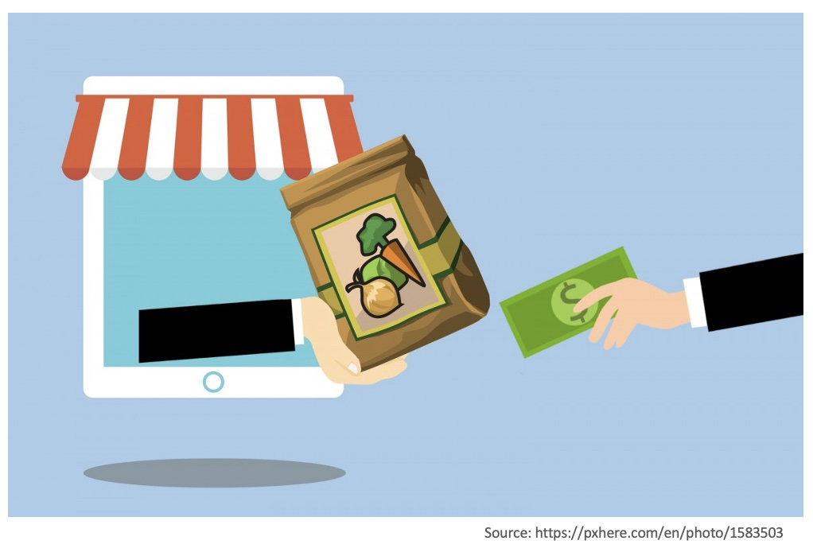

- **Buy Your Own Groceries**: This refers to the traditional way you would buy your groceries at a grocery store (i.e. in-person shopping).

### Delivery Price

Each grocery delivery will cost a flat fee regardless of the number of grocery deliveries. This includes all associated costs including tip. When you buy your own groceries there is no delivery price.

### Delivery Date

Delivery will be completed today, tomorrow, in 4 days, or in 7 days. Groceries will be delivered to the given location (described below). When you buy your own groceries, you can shop any day that fits your schedule.

### Delivery Agent

Delivery will be performed by either a human or an autonomous vehicle. This will not impact the delivery price, process, or timing in any way.

[figure not shown]

[figure not shown]

### Location

Grocery deliveries will be taken to one of three locations:

- **Doorstep**: Groceries will be placed, unsupervised, on your doorstep. For example, groceries will be placed on the front porch for single-family homes or outside the front door for apartment buildings.

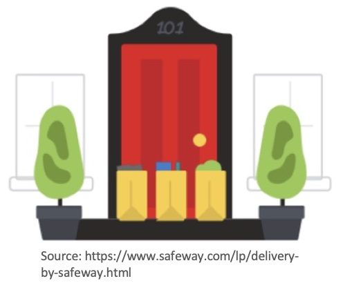

- **Curbside**: Groceries are delivered to your curbside, you will have to come and pick the groceries up from the delivery vehicle when it arrives.

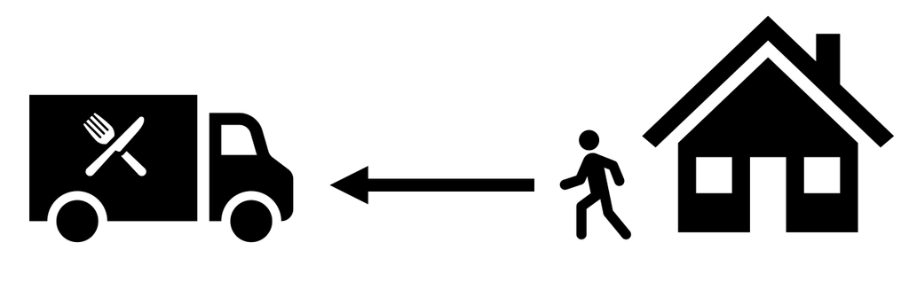

- **Neighborhood locker**: Groceries will be delivered to a secure, refrigerated locker that is within walking distance from your house.

[figure not shown]